# Pollution

Sondre Løvås

17 12 2020

# Introduction

In this project, air pollution from greenhouse gases are discussed. The motivation for the project is looking at what energy sources that the people of the world uses, that contributes the most towards global warming. Furthermore, it is looked into how nature is affected by global warming, and how decarbonization is evolving.

# Emission causes and effects

This graph shows how many million tonnes of greenhouse gasses that were released from 1990-2016, measured in the equivalent amount of carbon dioxide that would produce that same amount of energy.

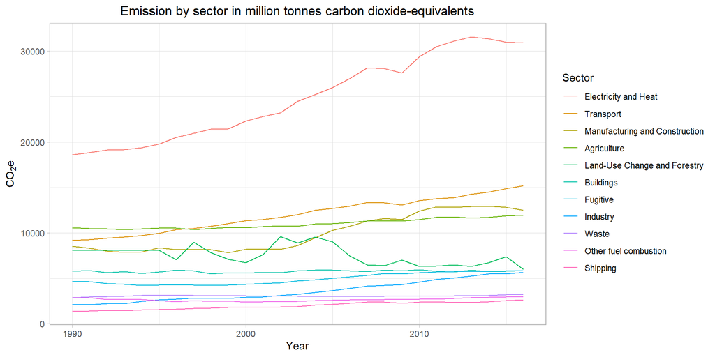

Source: Climate Watch Data Explorer

Electricity and heat seems to be a big contributor to greenhouse gases. Of the 102,812 million tonnes of greenhouse gases, electricity and heat makes out to be 30% of the total emission.

Transport, buildings, industries, electricity and heat all need a source of energy. Let’s look at the primary sources of energy the world consumes.

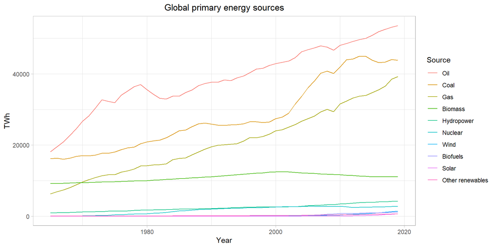

Source: [bp Statistical Review of World Energy](https://www.bp.com/en/global/corporate/energy-economics/statistical-review-of-world-energy.html)

As expected, coal, oil and gas are the worlds primary energy sources. The next visualization tries to emphasize this in a higher degree.

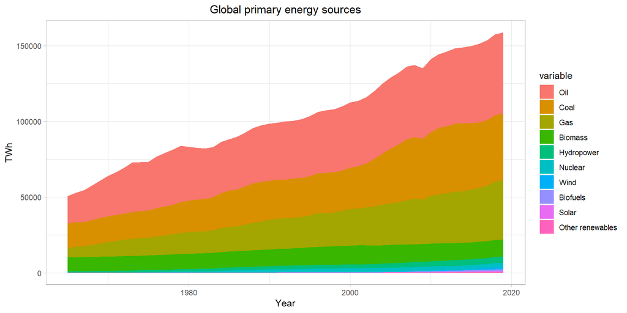

Source: [bp Statistical Review of World Energy](https://www.bp.com/en/global/corporate/energy-economics/statistical-review-of-world-energy.html)

The use of nonrenewable energy, and the greenhouse gases it emits, correlates to rising temperatures across the world. Under is a visualization of rising temperatures on both land and sea surface, and the amount of carbon dioxide emitted from fossil fuels.

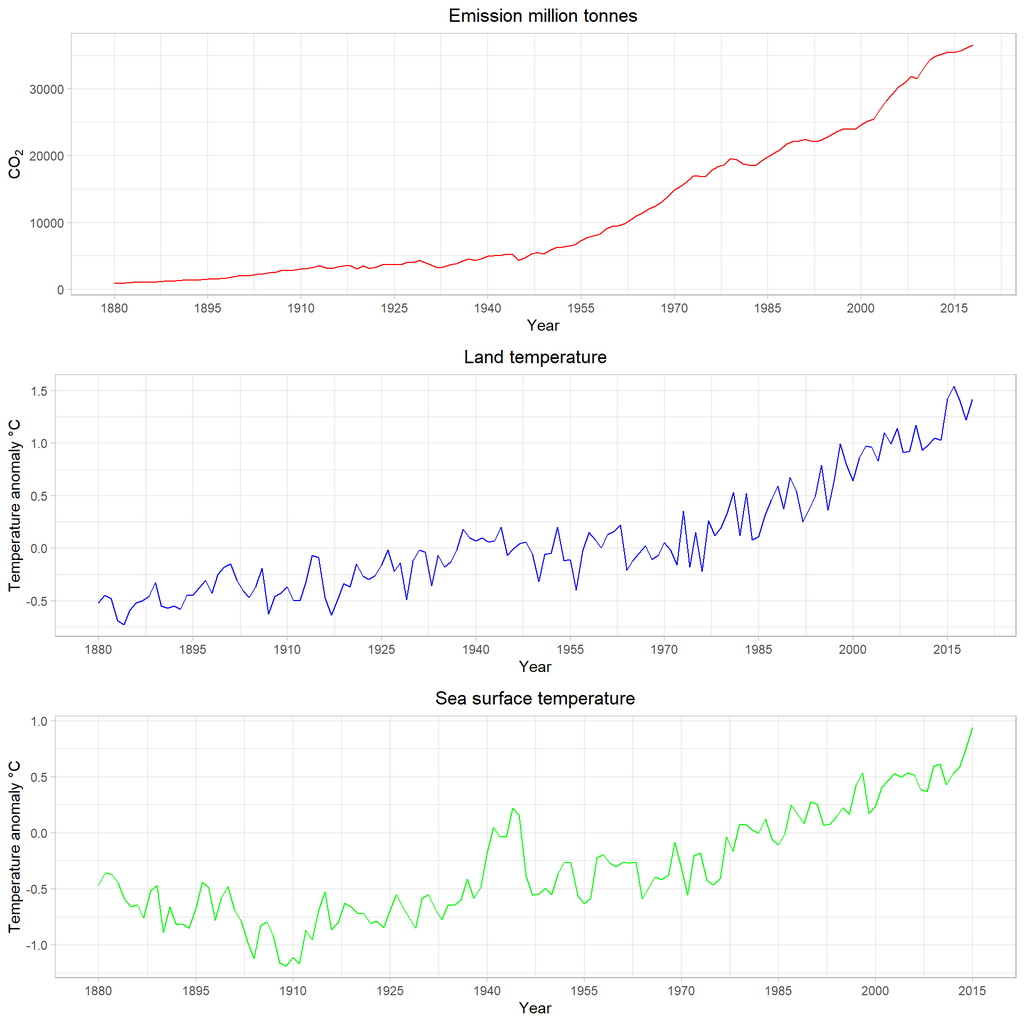

Source:  
CO<sub>2</sub>, Climate Watch  
Land temperature, [NOAA](https://www.ncdc.noaa.gov/cag/global/time-series/globe/land/ytd/12/1880-2019)  
Sea surface temperature, [EPA](https://www.epa.gov/climate-indicators/climate-change-indicators-sea-surface-temperature)

There is a 0.92 correlation between the rising land temperatures and carbon dioxide emissions. Using the temperature levels that were pre industrial revolution, the temperature has today as the plot shows, risen to an anomaly of approximately one degree Celsius.

Furthermore, ambient air pollution which is pollution from motor vehicles, oil and coal power plants, oil refineries etc. has resulted in 4,246,247 deaths across the globe in 2016. Research has also suggested that greenhouse gases has increased the frequency of natural disasters like hurricanes, floods, storms, droughts and wildfires$^{[1]}$.

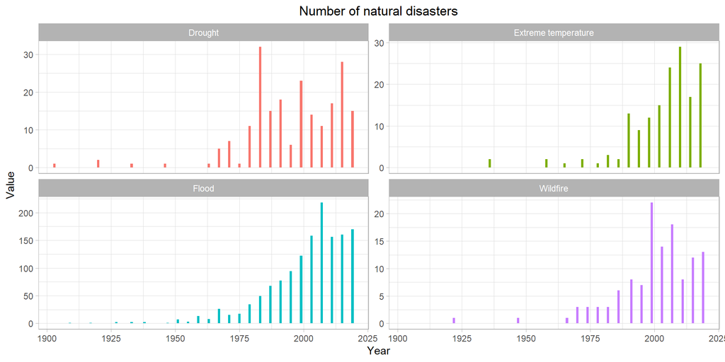

Source: [EM-DAT](https://www.emdat.be/)

Floods could be linked to rising sea levels which again is caused by melting ice. This graph shows changes in ice area in the Arctic.

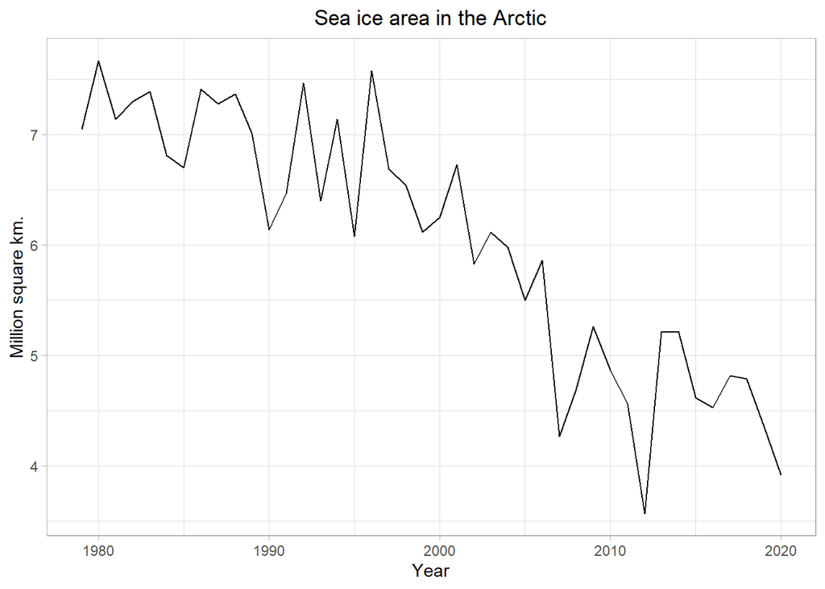

Source: [NASA climate](https://climate.nasa.gov/vital-signs/arctic-sea-ice/)

Here is a graph of changing water levels globally, and for some of the larger oceans in the world. The change is expressed in millimeters and the sea level is thought to be rising by an average of three millimeters a year.

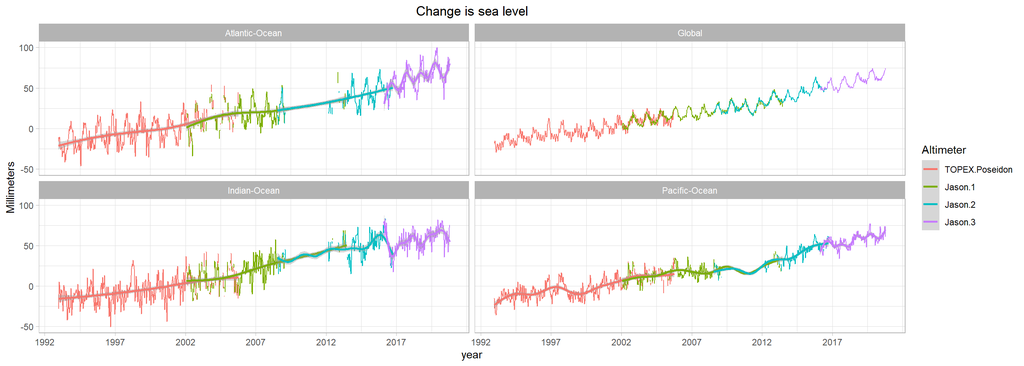

Source: [NOAA/NESDIS/STAR Laboratory for Satellite Altimetry](https://www.star.nesdis.noaa.gov/socd/lsa/SeaLevelRise/LSA_SLR_timeseries.php)

# Preventing increased pollution

The world is taking steps towards reducing our carbon footprint. The Paris agreement is an effort to reduce global greenhouse emissions and has set a goal that the global temperature will not exceed 2 degrees Celsius by the year 2100 or at best case 1.5 degrees Celsius. This primarily means that the use of fossil fuels has to decline and be replaced by renewable sources.

Dividing the renewable sources from the nonrenewable sources in the previous energy sources plot, it can bee seen that renewable energy has been on a heavy rise since around 2005.

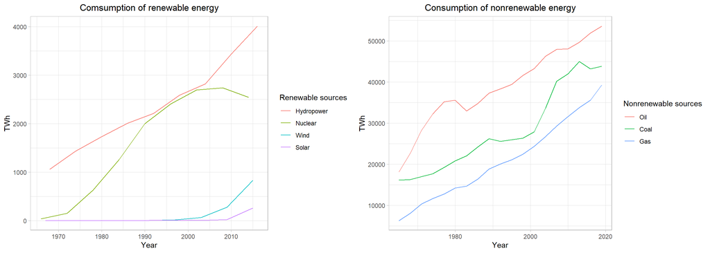

Source: [bp Statistical Review of World Energy](https://www.bp.com/en/global/corporate/energy-economics/statistical-review-of-world-energy.html)

Here, nuclear energy has been chosen to be added to the renewable sources. This is because research shows it is far safer than any nonrenewable sources and is close to being as safe as any of the other renewable sources on this graph. As the next chart shows, deaths because of nuclear energy is surprisingly low.

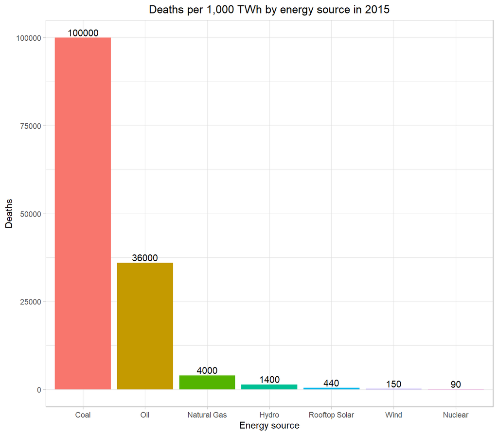

Source: [Cambridge House](https://cambridgehouse.com/news/7971/energy-metals-the-worlds-safest-source-of-energy-will-surprise-you)

Additionally, the CO<sub>2</sub> emissions from nuclear energy are very low, even lower than energy from wind and from photovoltaic sources$^{[2]}$. It even seems like the reliability of nuclear energy makes it cheaper, and in fact, it has one of the highest returns on investment$^{[3]}$. This can be shown by comparing the two neighboring countries France and Germany. Both has made efforts to reduce greenhouse gas emissions by switching to renewable sources, but their electricity prices are very different.

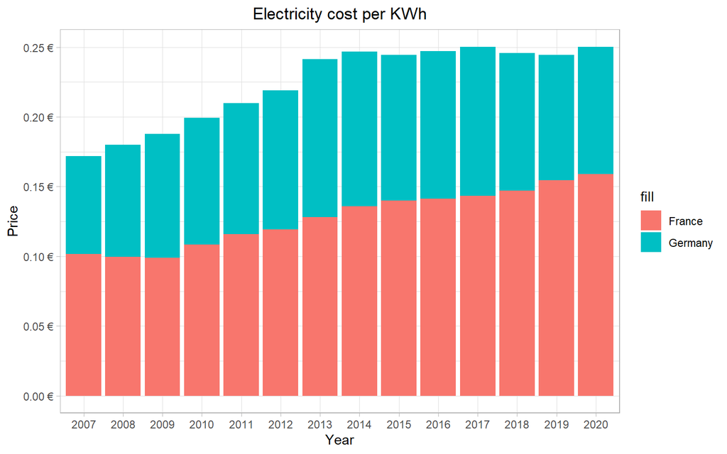

Source: [eia](https://www.eia.gov/)

The reason for this is thought to be the extended use of nuclear energy in France.

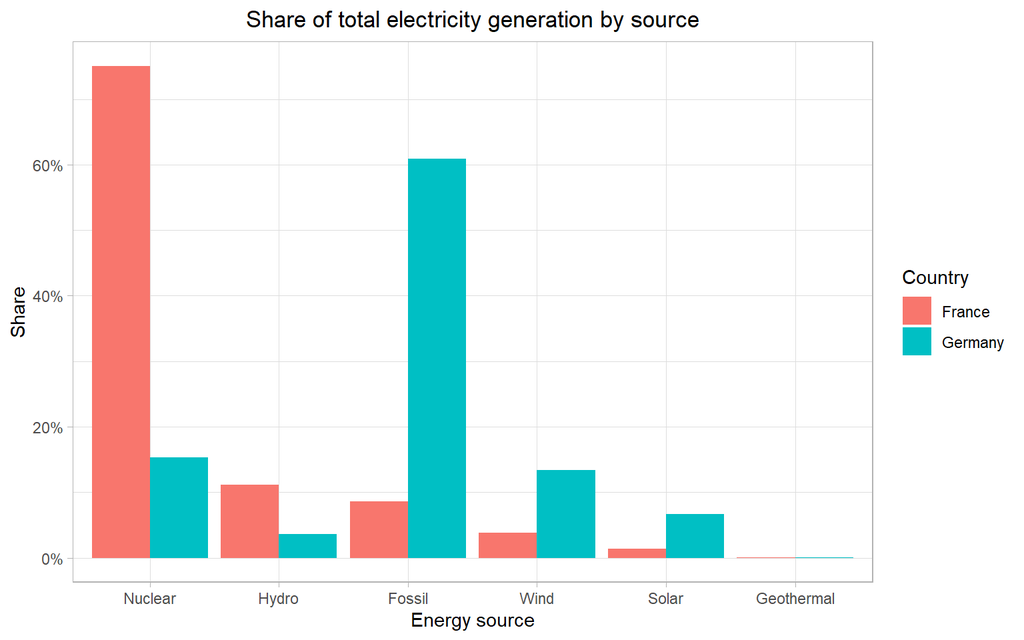

Source: [eia](https://www.eia.gov/)

The rise in renewable energy sources is partly an effect of greater investment in renewable energy sources, due to the current climate policies.

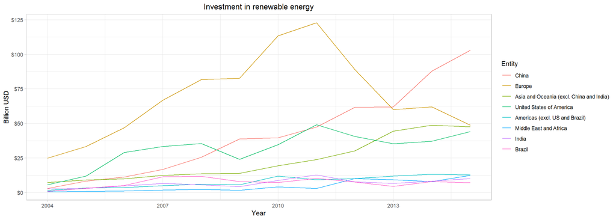

Source: [IRENA](http://resourceirena.irena.org/gateway/dashboard/)

After seeing which regions invest the most into renewable energies, lets look at which regions consumes the most renewable energy.

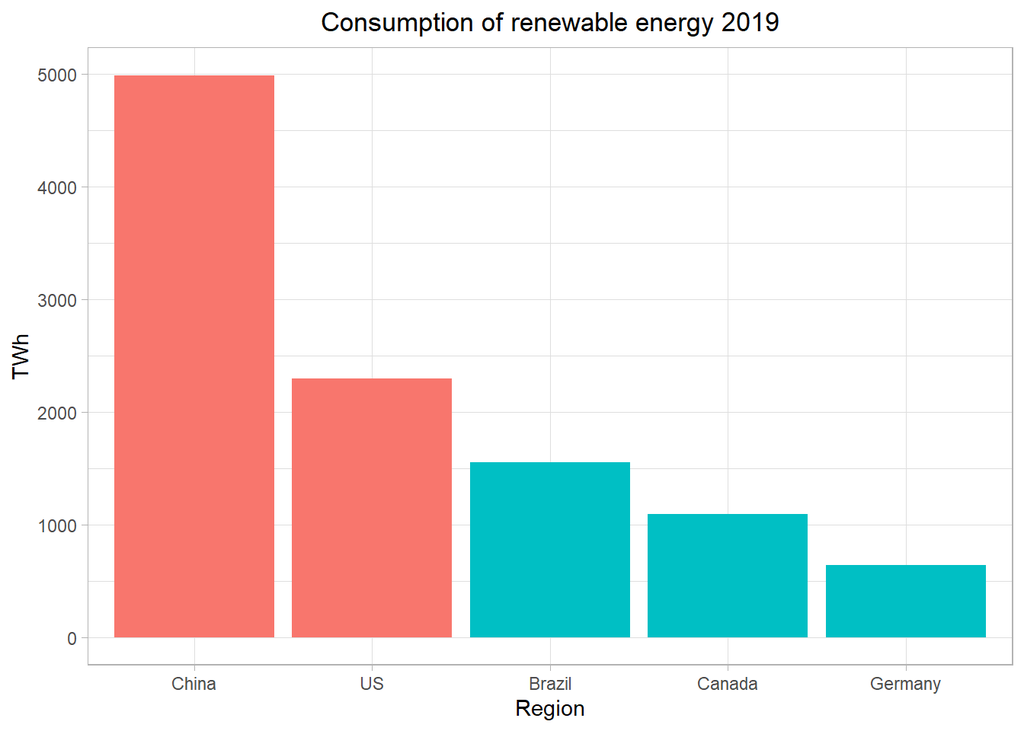

Source: [bp Statistical Review of World Energy](https://www.bp.com/en/global/corporate/energy-economics/statistical-review-of-world-energy.html)

From the graph it is seen that China and the US consumed the most renewable energy in 2019, but due to the population size of these countries, renewable energy per capita is quite low. This is seen in the next plot. It’s worth noting that the countries with the most renewable energy per capita is not included. These are Iceland and Denmark. The countries used are China and USA, with Finland, Germany and Sweden.

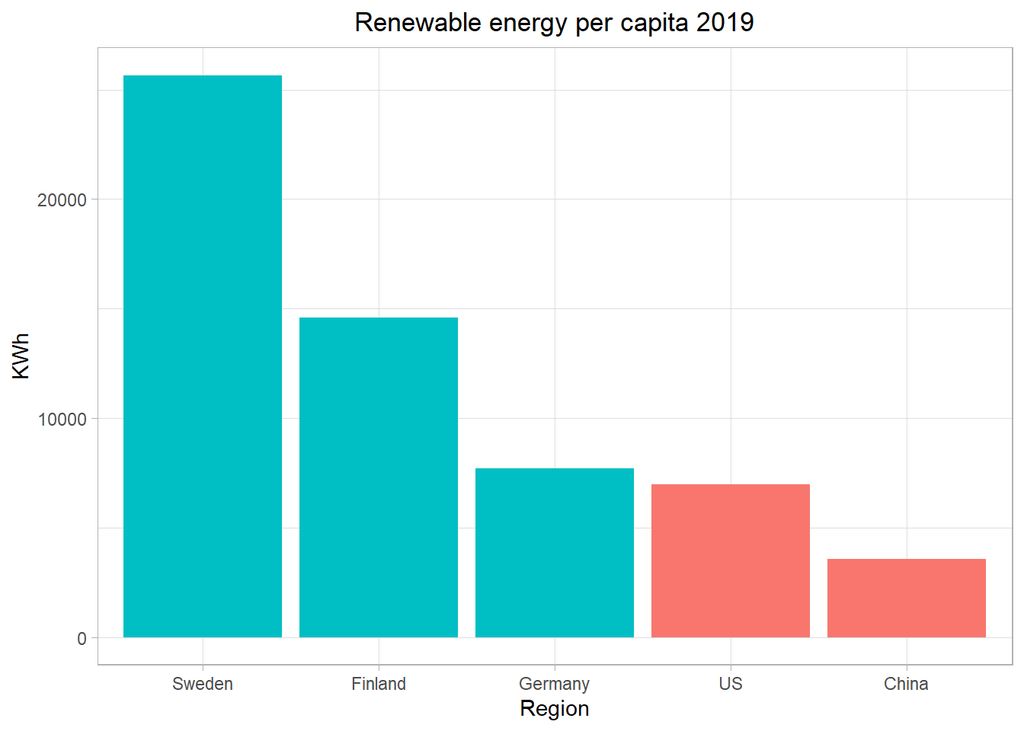

Source:  
Renewable energy, [bp Statistical Review of World Energy](https://www.bp.com/en/global/corporate/energy-economics/statistical-review-of-world-energy.html)  
Population, [The World Bank, DataBank](https://databank.worldbank.org/reports.aspx?source=2&series=SP.POP.TOTL&country=#)

As we can see, the larger countries must start investing much more into renewable sources to compensate for their large population sizes.

# Conclusions

Decreasing CO<sub>2</sub> emissions to stay clear of an 2.0 degree Celsius global temperature increase is no small feat, and for 1.5 degrees Celsius, nearly impossible. Here it is shown how much CO<sub>2</sub> emission the world has to drop to stay clear of these temperature increases by what year year we start in.

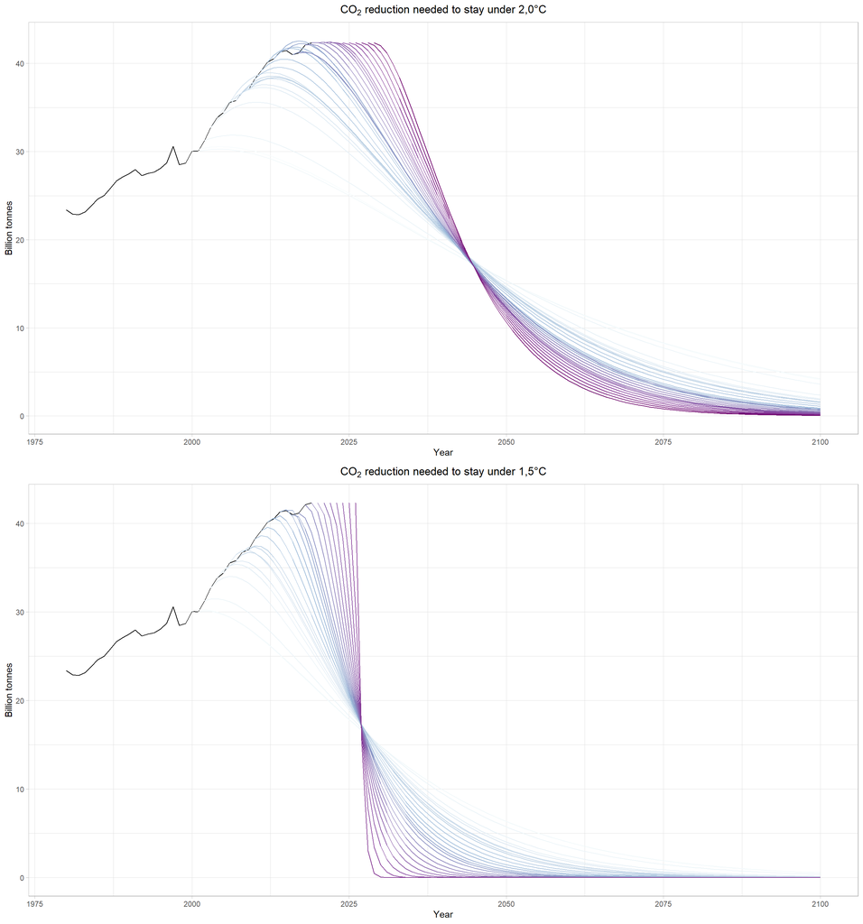

Source: [CICERO, Robbie Andrew](https://folk.universitetetioslo.no/roberan/t/global_mitigation_curves.shtml)

Analysis has estimated that with no climate policies implemented, the global temperature would rise to 4.1°C in 2100$^{[4]}$. Luckily the world is taking action and with current policies the temperature anomaly will hopefully stay under 3°C. To aid with this goal, more extensive use of nuclear energy is thought to be a good substitution to especially nonrenewable sources. Nuclear has low greenhouse gas emissions while it also preserves our nature from massive solar and wind farms.

## References

[1].Anderson, Jason, and Camilla Bausch. “Climate Change and Natural Disasters: Scientific evidence of a possible relation between recent natural disasters and climate change.” Policy Department Economic and Scientific Policy 2 (2006).  
[2].[NASA](https://www.giss.nasa.gov/meetings/pollution2002/summaryd.html)  
[3].[World Nuclear Org](https://www.world-nuclear.org/information-library/energy-and-the-environment/energy-return-on-investment.aspx) table 2.  
[4].[Climate Action Tracker](https://climateactiontracker.org/global/temperatures/)